# Reading, plotting and analysing localisation microscopy data

Bob Turner

## Reading Single molecule data into R

Single Molecule Localisation Microscopy (SMLM, PALM, STORM) software (e.g. ThunderSTORM, NSTORM) can output lists of molecule in text format (e.g. comma-seperated or tab-seperated). Here, we’re going to load one of these into R. Why do this? Getting the results into R gives access to all of the power of R’s plotting, analytical and data manipulation features. This is great for addressing one of the most frequently encountered questions in single molecule microscopy: “What went wrong?”!

I’ve used [ThunderSTORM](https://zitmen.github.io/thunderstorm/) to generate a molecule list using the [Tubulins I](http://bigwww.epfl.ch/smlm/challenge2013/datasets/Tubulins_I/index.html) dataset from EPFL. ThunderSTORM outputs are [localisations](https://bobturneruk.github.io/Tubulins_I.csv) and [protocol](https://bobturneruk.github.io/Tubulins_I-protocol.txt).

As usual, this is intended as a worked example and not production code. Drop me a line (bob dot turner dot uk at gmail dot com) with any feedback.

## Reading Data

One line is all it takes to read this into R as a data frame.

```r
Tubulins_I <- read.csv("https://bobturneruk.github.io/Tubulins_I.csv")
```

## Plotting Data

And another to plot it. **geom_bin2d** is a 2D histogram - it splits up the chart into square bins and colours these based on how many molecules are in each. I’ve used **drop = FALSE** so the background is coloured (as 0 localisations) using the same scale and added **coord_fixed()** so the x and y axes are on a 1:1 aspect ratio. **binwidth** is used here to set the size (in nm) of the bins i.e. the xy dimensions of the pixels.

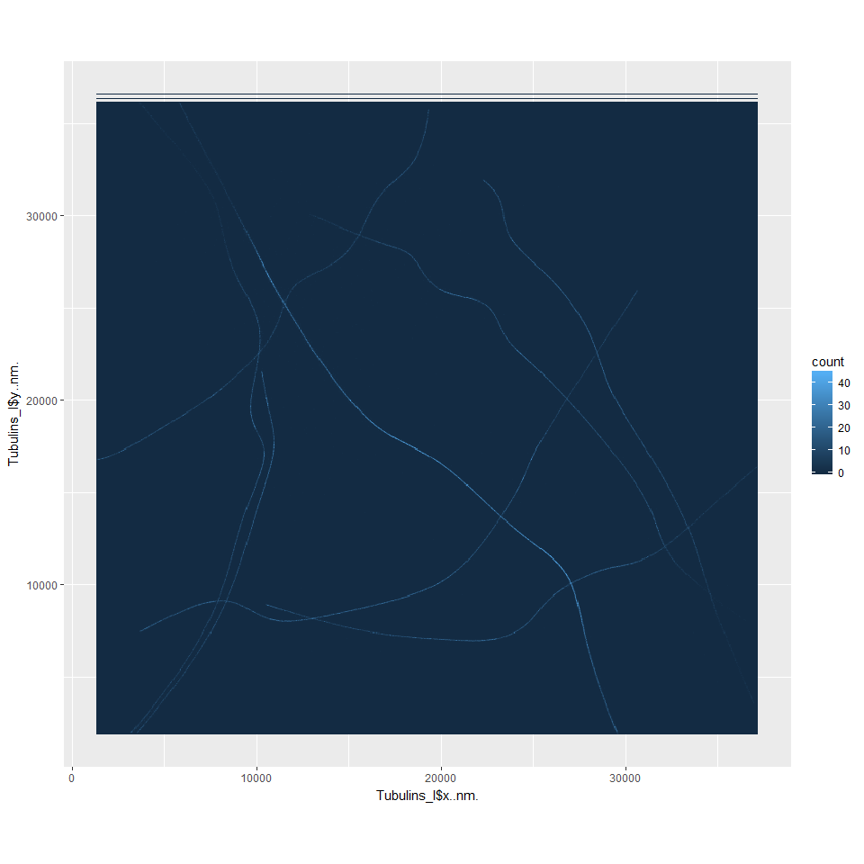

```r
library(ggplot2)
ggplot(Tubulins_I, aes(x=Tubulins_I$x..nm., y=Tubulins_I$y..nm.))+
  geom_bin2d(binwidth=50, drop = FALSE)+
  coord_fixed()
```